# Module 2, Lesson 2: Fitting a logistic regression against multiple variables

In this independent guide, we will learn how to fit a logistic regression model with multiple variables in R, which is usually called a *multiple* logistic regression model. To start, load the `healthds` and `tidyverse` packages in the usual way.

```r
library(healthds)
library(tidyverse)
```

### Fitting a multiple logistic regression model

We previously fit a simple logistic regression model to the `BPUrban1000` data, estimating the association between a person’s hypertension status (recorded as yes/no outcome) and whether they are a smoker. Now, we will expand that model to adjust for both smoking status *and* the person’s age. As before, we will use the `glm` function:

```r
htn_smk_age_model <-
  BPUrban1000 %>%
  glm(formula = hypertension ~ smoking + age, family = "binomial")
```

Compared to a simple logistic regression model, what has changed is that we have “added” `age` to the right-hand side of the formula.

### Interpreting a multiple logistic regression model

However, we can calculate the log-odds of hypertension for other age/smoking combinations, e.g. the log-odds of hypertension for a 63-year-old non-smoker would be given by $\beta_0 + \beta_2 \times 63$, and the log-odds of hypertension for a 63-year-old smoker would be given by $\beta_0 + \beta_1 + \beta_2\times 63$. Taking the difference of these two quantities, and noting that the contribution due to each person’s age cancels out upon taking this difference, we also see that the *change* in log-odds between smokers and non-smokers who are *the same age* is $\beta_1$. It does not matter what age we plug in here, as long as the age is the same between the two people, because the contribution due to each person’s age would always cancel out. For this reason, instead of writing ‘who are the same age’, one could also write ‘adjusting for age’ or ‘holding age constant’. Note that this interpretation differs from $\beta_1$ in the previous lesson on simple logistic regression, which did not include age.

The log-odds for a 64-year-old non-smoker is $\beta_0 + \beta_2\times 64$. Thus, the difference between this quantity and the log-odds of hypertension for a 63-year-old non-smoker is $(\beta_0 + \beta_2\times 64) - (\beta_0 + \beta_2\times 63)$, or just $\beta_2$. Similarly, the log-odds for a 64-year-old smoker is $\beta_0 + \beta_1+\beta_2\times 64$; the difference between this quantity and the log-odds of hypertension for a 63-year-old smoker is *also* $\beta_2$. In general, $\beta_2$ is interpreted as the change in the log-odds of hypertension for each year increase in age, adjusting for smoking status.

As with simple logistic regression, any log-odds can be turned into more intuitive quantities, such as odds or probabilities, using mathematical operations. Specifically, following the same steps as in the previous lesson, the probability of hypertension in general is $\exp\{\beta_0+\beta_1\mathrm{smoker}+\beta_2\mathrm{age}\}/(1+\exp\{\beta_0+\beta_1\mathrm{smoker}+\beta_2\mathrm{age}\})$, where you provide the value for ‘smoker’ and ‘age’, corresponding to the person who’s probability you are trying to calculate.

### Obtaining numerical summaries of logistic regressions

Running the above code will (i) fit the model and (ii) save the result in a new object called `htn_smk_age_model`. We again use the `summary` function, as in the previous lesson, to inspect the fitted model and conduct inference:

```r
summary(htn_smk_age_model)
```

```
##
## Call:
## glm(formula = hypertension ~ smoking + age, family = "binomial",
##     data = .)
##
## Deviance Residuals:
##     Min       1Q   Median       3Q      Max
## -1.6115  -0.7028  -0.4221  -0.1569   3.0280
##
## Coefficients:
##              Estimate Std. Error z value Pr(>|z|)
## (Intercept) -6.592025   0.514575 -12.811  < 2e-16 ***
## smokingTRUE  0.784743   0.284144   2.762  0.00575 **
## age          0.091716   0.008342  10.995  < 2e-16 ***
## ---
## Signif. codes:  0 '***' 0.001 '**' 0.01 '*' 0.05 '.' 0.1 ' ' 1
##
## (Dispersion parameter for binomial family taken to be 1)
##
##     Null deviance: 1033.19  on 999  degrees of freedom
## Residual deviance:  847.97  on 997  degrees of freedom
## AIC: 853.97
##
## Number of Fisher Scoring iterations: 5
```

The `(Intercept)` parameter in the first row of the `Coefficient` section is the estimate of $\beta_0$, the log-odds of hypertension for non-smokers who are zero years old, and it is estimated to be approximately -6.5920, with a standard error of 0.5146. This is a much smaller value than that estimated in the previous lesson, and this is because the interpretation is much different, as discussed above.

Looking in the second row, `smokingTRUE` gives the estimate of $\beta_1$, which is the *change in the log-odds* of hypertension between non-smokers and smokers, adjusting for age. It is 0.7847, meaning that the log-odds of hypertension are larger for a smoker as compared to a non-smoker of the same age, and the p-value in the last column is 0.00575, which suggests that this change is statistically significant. If we exponentiate this change in the log-odds, i.e. exp{0.7847}, we obtain the odds ratio of hypertension between non-smokers and smokers, adjusting for age. This value is 2.192, which means that the odds of hypertension are 2.192 greater for smokers than they are for non-smokers, adjusting for age.

From the third row, `age` gives the estimate of $\beta_2$, which is the change in log-odds per year increase in age, adjusting for the person’s smoking status. It is highly statistically significant, with the p-value being less than $2\times 10^{-16}$ (R’s way of writing this is `2e-16`). Note that, $\beta_2$ and $\beta_1$ aren’t directly comparable, and we can’t conclude from this that smoking has a more meaningful or larger association with hypertension than age simply because the estimate of $\beta_1$ is larger than that of $\beta_2$. $\beta_1$ is a qualitative comparison between smokers and non-smokers, whereas $\beta_2$ gives a change with increasing age. In fact, we can straightforwardly calculate the change in log-odds of hypertension for an age differential that is more than one year. For example, the estimated change in the log-odds of hypertension between a 53-year-old non-smoker and a 63-year-old non-smoker is 0.09172 $\times$ 10 (because they are ten years apart), or 0.9172.

### Predictions using `predict` function

We can use this model to calculate the predicted probability of hypertension for any age/smoking combination. For example, the predicted probability of hypertension for a 63-year-old non-smoker is exp{-6.5920+63 $\times$ 0.09172}/ (1+exp{-6.5920+63 $\times$ 0.09172}), or 0.3071. If this person were a smoker, their predicted probability of hypertension would be exp{-6.5920+0.7847+63 $\times$ 0.09172}/(1+exp{-6.5920+0.7847+63 $\times$ 0.09172}), or 0.4928.

However, it is tedious and error-prone to calculate probabilities by hand. Fortunately, the `predict` function in R can do so automatically. A common way to use this function is as follows:

```r
htn_smk_age_model %>%
  predict() %>% # by default 'predict' will calculate the log-odds (or linear predictors)
  head()
```

```
##          1          2          3          4          5          6
## -0.8139073 -3.8405406 -4.3908375 -1.8227851 -0.9973396 -2.0062174
```

If you provide a fitted logistic regression model to `predict`, as we do above, then the function will calculate the log-odds for the observations in the data that were used to estimate the model. In this case, those are the 1000 people in the `BPUrban1000`. Instead of looking at all 1000 people, above we use the `head` function to inspect just the first six persons’ log-odds of hypertension.

If instead we wanted the predicted probabilities of hypertension, we would use the following:

```r
htn_smk_age_model %>%
  predict(type = "response") %>% # type = "response" will result in predicted probabilities
  head()
```

```
##          1          2          3          4          5          6
## 0.30705850 0.02103021 0.01223871 0.13910002 0.26946480 0.11855168
```

Specifying `type = "response"` inside of `predict` is how we instruct R to return the probabilities themselves rather than the log-odds. We can compare these results to what we calculated “by hand”. The first six rows of the `BPUrban1000` dataset are as follows:

```r
head(BPUrban1000)
```

```
##   hypertension systolic diastolic  bmi  bmi_group cholesterol age age_group
## 1            0      136        59 35.0  BMI>27.49         183  63      >=60
## 2            0      134        90 18.4 BMI<=27.49         127  30     30-44
## 3            1      149        76 28.1  BMI>27.49         132  24     20-29
## 4            0      117        65 29.1  BMI>27.49         126  52     45-59
## 5            0      110        74 33.1  BMI>27.49         182  61      >=60
## 6            0      102        65 26.0 BMI<=27.49          96  50     45-59
##   parent_history_HTN salt  salt_group smoking chewing  activity weight
## 1             either  1.5     Salt<=5   FALSE    TRUE sedentary   82.1
## 2               both  9.1  5<Salt<=10   FALSE   FALSE  moderate   49.3
## 3             either 15.2 10<Salt<=20   FALSE    TRUE    severe   78.1
## 4               none  6.0  5<Salt<=10   FALSE   FALSE  moderate   66.6
## 5               none 13.8 10<Salt<=20   FALSE   FALSE  moderate   73.4
## 6               both 11.5 10<Salt<=20   FALSE   FALSE      mild   62.7
##   waist_circumference hip_circumference waist_hip_ratio fasting_glucose
## 1                61.9              82.3            0.75              75
## 2                99.1              93.7            1.06             130
## 3               101.1              88.9            1.14             129
## 4                88.7             100.5            0.88             126
## 5                60.4              81.8            0.74              76
## 6                60.0              78.5            0.77              68
##            caste marital_status religion  education gender
## 1 Schedule tribe        Married   Muslim >=Graduate Female
## 2    Other caste        Married     Sikh >=Graduate   Male
## 3        General        Married    Hindu  <=Primary Female
## 4        General      Unmarried    Hindu     Middle Female
## 5 Schedule caste      Unmarried    Hindu  <=Primary Female
## 6        General        Married    Hindu  <=Primary Female
```

In particular, the first person is a 63-year-old non-smoker, for whom we have already calculated a predicted probability of 0.3071 (up to four significant digits). This matches the output from `predict`. Manually calculate on your own the predicted probability of hypertension for the second subject in the data, a 30-year-old non-smoker; if your calculations are correct, you should obtain a value of 0.02103, consistent with the output from `predict`.

### Visualizing a logistic regression model

To finish, we will learn how to visualize a fitted regression model. In Course 1, we saw that the `mutate` function in the `tidyverse` lets one add new variables to a dataframe. We will add a new variable to `BPUrban1000` that records that persons predicted probability of hypertension:

```r
BPUrban1000 %>%
  mutate(pred_htn_prob = htn_smk_age_model %>% predict(type = "response")) %>%
  head()
```

```
##   hypertension systolic diastolic  bmi  bmi_group cholesterol age age_group
## 1            0      136        59 35.0  BMI>27.49         183  63      >=60
## 2            0      134        90 18.4 BMI<=27.49         127  30     30-44
## 3            1      149        76 28.1  BMI>27.49         132  24     20-29
## 4            0      117        65 29.1  BMI>27.49         126  52     45-59
## 5            0      110        74 33.1  BMI>27.49         182  61      >=60
## 6            0      102        65 26.0 BMI<=27.49          96  50     45-59
##   parent_history_HTN salt  salt_group smoking chewing  activity weight
## 1             either  1.5     Salt<=5   FALSE    TRUE sedentary   82.1
## 2               both  9.1  5<Salt<=10   FALSE   FALSE  moderate   49.3
## 3             either 15.2 10<Salt<=20   FALSE    TRUE    severe   78.1
## 4               none  6.0  5<Salt<=10   FALSE   FALSE  moderate   66.6
## 5               none 13.8 10<Salt<=20   FALSE   FALSE  moderate   73.4
## 6               both 11.5 10<Salt<=20   FALSE   FALSE      mild   62.7
##   waist_circumference hip_circumference waist_hip_ratio fasting_glucose
## 1                61.9              82.3            0.75              75
## 2                99.1              93.7            1.06             130
## 3               101.1              88.9            1.14             129
## 4                88.7             100.5            0.88             126
## 5                60.4              81.8            0.74              76
## 6                60.0              78.5            0.77              68
##            caste marital_status religion  education gender pred_htn_prob
## 1 Schedule tribe        Married   Muslim >=Graduate Female    0.30705850
## 2    Other caste        Married     Sikh >=Graduate   Male    0.02103021
## 3        General        Married    Hindu  <=Primary Female    0.01223871
## 4        General      Unmarried    Hindu     Middle Female    0.13910002
## 5 Schedule caste      Unmarried    Hindu  <=Primary Female    0.26946480
## 6        General        Married    Hindu  <=Primary Female    0.11855168
```

The code above creates this variable and shows just the first six rows of the resulting augmented dataset (printing the entire dataset would result in pages and pages of results). The very last column is the newly created `pred_htn_prob` variable.

We can now expand this code to visualize how the predicted probability of hypertension changes with age and smoking status. Using the `ggplot` functionality that we learned in Course 1, we will create a scatter plot, mapping `age` to the x aesthetic, `pred_htn_prob` to the y aesthetic, and `smoking` to the color aesthetic.

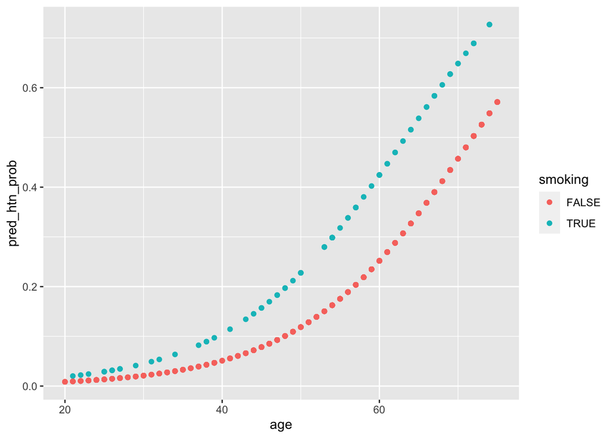

```r
BPUrban1000 %>%
  mutate(pred_htn_prob = htn_smk_age_model %>% predict(type = "response")) %>%
  ggplot() +
  geom_point(aes(x = age, y  = pred_htn_prob, color = smoking))
```

Each point of this scatter plot represents a predicted probability for a unique combination of age/smoking status; only those combinations appearing in our data are plotted. There are gaps in places where there were no observations in the data that had that combination, e.g. there are no 40-year-old smokers in the dataset. Importantly, this absence of data does not preclude us from using our model to predict the probability of hypertension for a 40-year-old smoker, and it could be appropriate to do so since we *do* have data on both younger and older smokers and data on 40-year-old non-smokers.

Visualizations on the probability scale, like this, can be useful for communicating the implications of a fitted model, which can otherwise be difficult to understand since log-odds and changes in log-odds are not intuitive quantities. Here, we see that the model estimates that the probability of hypertension among people younger than 30 years old is quite small, even for smokers. On the other hand, among older people, smoking tends to correspond to a much greater probability of hypertension. An important statistical lesson here is that even though a logistic regression model may estimate a constant change in log-odds between two groups (in this case, smokers versus non-smokers), once we transform to the probability scale, this won’t generally correspond to a constant change in the probability of the outcome, i.e. the difference between the heights of the two color dots is not constant with age.